# (Des) Motivación

Nelson Berrezueta

2/7/2020

## ¿Qué más se puede exprimir de un análisis de tiempo?

Hace algún tiempo tuve la oportunidad de realizar un análisis de tiempos en una empresa que mantiene varias oficinas en distintos puntos del país. El objetivo fue generar los tiempos estándar de cada uno de los procesos.

Al finalizar el análisis básico que nos enseñan en la universidad: tomar tiempos, quitar eventos atípicos, calcular promedios y añadir suplementos… Decidí investigar un poco más, solo con el afán de divertirme un poco, al fin y al cabo los datos ya los tenía.

Quise responder preguntas del tipo: ¿qué relación existe entre el tiempo del proceso y la cantidad de dinero? ¿hay mayor relación entre el tiempo y el monto o la cantidad de billetes? ¿las personas siguen la curva normal de aprendizaje?

Respondí a la última pregunta usando el software R, con las siguientes librerías:

```r
library(openxlsx)
library(tidyverse)
library(rapportools)
```

## Datos disponibles

La base de datos inicial contiene 18 variables y más de 600 observaciones, es decir, tomas de tiempo que se realizaron en distintas oficinas de la empresa, en total 6, distribuidas por región del Ecuador: Costa, Sierra y Oriente (Amazonía). Se tomaron a personas con experienicia de 0 a 6 años en 4 transacciones diferentes (A, B, C y D), el monto transaccionado, la cantidad de billetes, el tiempo en minutos que demoraron y la cantidad de dinero que tuvieron que contar para realizar una transacción.

El set de datos es el siguiente. Como se ve, la Oficina y los años de experiencia se muestran como un datos de tipo dbl, es decir, de tipo numérico en R. Se procede a cambiar a tipo caracter y factor para realizar los análisis correspondientes.

```r
head(data)
```

```
## # A tibble: 6 x 18
##   OFICINA REGION EXPERIENCIA TRANSACCION MONTO  B100   B50   B20   B10    B5
##     <dbl> <chr>        <dbl> <chr>       <dbl> <dbl> <dbl> <dbl> <dbl> <dbl>
## 1       1 SIERRA           0 TRAN_A      25500     5    NA  1000   500    NA
## 2       6 COSTA            1 TRAN_B       2000    NA    NA   100    NA    NA
## 3       1 SIERRA           0 TRAN_B      10000    NA    NA   400   200    NA
## 4       1 SIERRA           0 TRAN_A       5000    20    NA   100   100    NA
## 5       8 COSTA            2 TRAN_A       4645    11     2   146    52     1
## 6       1 SIERRA           0 TRAN_B       3050   100     1   100    NA    NA
## # ... with 8 more variables: M1 <dbl>, M0.5 <dbl>, M0.25 <dbl>, M0.1 <dbl>,
## #   M0.05 <dbl>, M0.01 <dbl>, MINUTOS <dbl>, ESPECIES <dbl>
```

Ahora la oficina se muestra como caracter y la experiencia como factor ordenado. También selecciono solamente las columnas que interesan para los análisis, omitiendo la cantidad de billetes de cada tipo.

```r
consolidado <- data %>%
  dplyr::select(OFICINA, REGION, EXPERIENCIA, TRANSACCION,
                MONTO, ESPECIES, MINUTOS) %>%
  dplyr::mutate(OFICINA = as.character(OFICINA),
                EXPERIENCIA = as.character(EXPERIENCIA)) %>%
  dplyr::mutate(EXPERIENCIA = parse_factor(EXPERIENCIA,
                                           levels = c("0","1","2","5","6"),
                                           ordered = TRUE))
```

| OFICINA | REGION | EXPERIENCIA | TRANSACCION | MONTO | ESPECIES | MINUTOS |
| --- | --- | --- | --- | --- | --- | --- |
| 1 | SIERRA | 0 | TRAN_A | 25500 | 1505 | 14.975333 |
| 6 | COSTA | 1 | TRAN_B | 2000 | 100 | 0.809500 |
| 1 | SIERRA | 0 | TRAN_B | 10000 | 600 | 4.790000 |
| 1 | SIERRA | 0 | TRAN_A | 5000 | 220 | 6.462167 |
| 8 | COSTA | 2 | TRAN_A | 4645 | 212 | 6.321167 |
| 1 | SIERRA | 0 | TRAN_B | 3050 | 201 | 3.332667 |

Ahora identifico los datos atípicos, la función rp.outlier del paquete rapportools es muy útil para esta tarea. Esta función genera un vector con los puntos atípicos encontrados. Yo suelo iterar filtrando los datos hasta que no me muestre outliers. En este caso, las medidas mayores a 4.87 minutos son mostradas como atípicos, el resto no. Filtro los datos menores a dicho valor.

```r
rp.outlier(consolidado$MINUTOS)
```

```
## [1] 14.975333 16.370167 15.991833 13.567167  8.211167
```

```r
consolidado <- consolidado %>%
  filter(MINUTOS <= 4.87)
```

## Curva de aprendizaje

Ahora se puede generar un primer gráfico para conocer el estado de los años de experiencia de una persona vs. el tiempo que le toma realizar una transacción.

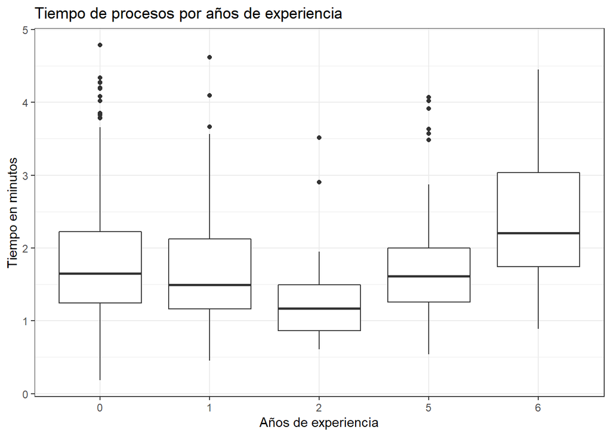

```r
consolidado %>%
  ggplot(aes(x=EXPERIENCIA))+
  geom_boxplot(aes(y=MINUTOS))+
  labs(title = "Tiempo de procesos por años de experiencia", x="Años de experiencia",
       y="Tiempo en minutos")+
  theme_bw()
```

¿Ves algo raro? ¡Vamos! ¿Es “normal” lo que muestra este gráfico? Una curva de aprendizaje normal tiende a ser más alta al principio y luego estabilizarse según pasa el tiempo hasta llegar a una asíntota de la cual no baja más, es decir, un punto en el que la persona conoce el proceso, lo realiza correcta y rápidamente. Sin embargo en este caso hay algo raro… La curva no parece asintótica, no se estabiliza, es más… ¡Parece una parábola! ¿Esto qué quiere decir? Si si, yo se que no se están tomando los 6 años completos, es porque las personas con quienes se levantaron los tiempos tenían 0, 1, 2, 5 o 6 años de experiencia, pero aunque no tenemos datos para 3 o 4 años de experiencia se pueden generar ciertas suposiciones.

Con este boxplot se puede intuir que a los 2 años de estar en el puesto, la persona ya conoce el proceso, lo tiene interiorizado, comete pocos errores y tiene una variablidad menor respecto a los primeros años. Esto es completamente normal en los estudios de trabajo.

¿Pero qué sucede después de los 2 años? Bueno, a los 5 años la variabilidad sigue siendo baja, pero el tiempo comienza a incrementarse y los puntos atípicos también son más frecuentes.

¿Y al sexto año? Claramente el tiempo del proceso es mucho mayor, ¡incluso mayor a los nuevos empleados! También, la variabilidad es muy alta, y lo que es peor, no hay puntos atípicos si no que ya los tiempos altos se toman como eventos normales…

Este hecho fue comunicado al departamento de talento humano para que analice si debe tomar medidas al respecto, ya que para mi criterio, se demuestra cierta ausencia de motivación en los empleados de mayor experiencia, hasta tal punto que llegan a estar tan relajados que no rinden ni siquiera al nivel de una persona que acaba de incorporarse al trabajo.

Digo yo que 5 o 6 años en el mismo lugar de trabajo… desmotiva a cualquiera, ¿no?